# LoanTap Business Case

# Data Preprocessing

```python
df.duplicated().sum()
```

```
0
```

There is No Duplicate values are present in the Data set

## Analyse the Missing Values

```python
df.isna().sum()
```

```
loan_amnt                   0
term                        0
int_rate                    0
installment                 0
grade                       0
sub_grade                   0
emp_length              18301
home_ownership              0
annual_inc                  0
verification_status         0
loan_status                 0
purpose                     0
dti                         0
open_acc                    0
pub_rec                     0
revol_bal                   0
revol_util                276
total_acc                   0
initial_list_status         0
application_type            0
mort_acc                37795
pub_rec_bankruptcies      535
earliest_year               0
pin_code                    0
issue_d_year                0
dtype: int64
```

```python
Missing_values = df[['emp_length','revol_util', 'mort_acc', 'pub_rec_bankruptcies']]
Missing_values.isna().sum()
```

```
emp_length              18301
revol_util                276
mort_acc                37795
pub_rec_bankruptcies      535
dtype: int64
```

```python
column_mode = df['emp_length'].mode()[0]
df['emp_length'] = df['emp_length'].fillna(column_mode)
```

```python
si = SimpleImputer(strategy = 'mean')
df['mort_acc'] = si.fit_transform(df[['mort_acc']])
```

```python
si = SimpleImputer(strategy = 'mean')
df['pub_rec_bankruptcies'] = si.fit_transform(df[['pub_rec_bankruptcies']])
```

```python
si = SimpleImputer(strategy = 'mean')
df['revol_util'] = si.fit_transform(df[['revol_util']])
```

```python
df.isna().sum()
```

```
loan_amnt               0
term                    0
int_rate                0
installment             0
grade                   0
sub_grade               0
emp_length              0
home_ownership          0
annual_inc              0
verification_status     0
loan_status             0
purpose                 0
dti                     0
open_acc                0
pub_rec                 0
revol_bal               0
revol_util              0
total_acc               0
initial_list_status     0
application_type        0
mort_acc                0
pub_rec_bankruptcies    0
earliest_year           0
pin_code                0
issue_d_year            0
dtype: int64
```

```python
df.describe()
```

|  | loan_amnt | int_rate | installment | annual_inc | dti | open_acc | pub_rec | revol_bal | revol_util | total_acc | mort_acc | pub_rec_bankruptcies | issue_d_year |
| --- | --- | --- | --- | --- | --- | --- | --- | --- | --- | --- | --- | --- | --- |
| count | 396030.000000 | 396030.000000 | 396030.000000 | 3.960300e+05 | 396030.000000 | 396030.000000 | 396030.000000 | 3.960300e+05 | 396030.000000 | 396030.000000 | 396030.000000 | 396030.000000 | 396030.000000 |
| mean | 14113.888089 | 13.639400 | 431.849698 | 7.420318e+04 | 17.379514 | 11.311153 | 0.178191 | 1.584454e+04 | 53.791749 | 25.414744 | 1.813991 | 0.121648 | 2013.629074 |
| std | 8357.441341 | 4.472157 | 250.727790 | 6.163762e+04 | 18.019092 | 5.137649 | 0.530671 | 2.059184e+04 | 24.443671 | 11.886991 | 2.042867 | 0.355934 | 1.481725 |
| min | 500.000000 | 5.320000 | 16.080000 | 0.000000e+00 | 0.000000 | 0.000000 | 0.000000 | 0.000000e+00 | 0.000000 | 2.000000 | 0.000000 | 0.000000 | 2007.000000 |
| 25% | 8000.000000 | 10.490000 | 250.330000 | 4.500000e+04 | 11.280000 | 8.000000 | 0.000000 | 6.025000e+03 | 35.900000 | 17.000000 | 0.000000 | 0.000000 | 2013.000000 |
| 50% | 12000.000000 | 13.330000 | 375.430000 | 6.400000e+04 | 16.910000 | 10.000000 | 0.000000 | 1.118100e+04 | 54.800000 | 24.000000 | 1.000000 | 0.000000 | 2014.000000 |
| 75% | 20000.000000 | 16.490000 | 567.300000 | 9.000000e+04 | 22.980000 | 14.000000 | 0.000000 | 1.962000e+04 | 72.900000 | 32.000000 | 3.000000 | 0.000000 | 2015.000000 |
| max | 40000.000000 | 30.990000 | 1533.810000 | 8.706582e+06 | 9999.000000 | 90.000000 | 86.000000 | 1.743266e+06 | 892.300000 | 151.000000 | 34.000000 | 8.000000 | 2016.000000 |

```python
df.describe(include='category')
```

|  | term | grade | sub_grade | emp_length | home_ownership | verification_status | loan_status | purpose | initial_list_status | application_type | earliest_year | pin_code |
| --- | --- | --- | --- | --- | --- | --- | --- | --- | --- | --- | --- | --- |
| count | 396030 | 396030 | 396030 | 396030 | 396030 | 396030 | 396030 | 396030 | 396030 | 396030 | 396030 | 396030 |
| unique | 2 | 7 | 35 | 11 | 6 | 3 | 2 | 14 | 2 | 3 | 65 | 10 |
| top | 36 months | B | B3 | 10+ years | MORTGAGE | Verified | Fully Paid | debt_consolidation | f | INDIVIDUAL | 2000 | 70466 |
| freq | 302005 | 116018 | 26655 | 144342 | 198348 | 139563 | 318357 | 234507 | 238066 | 395319 | 29366 | 56985 |

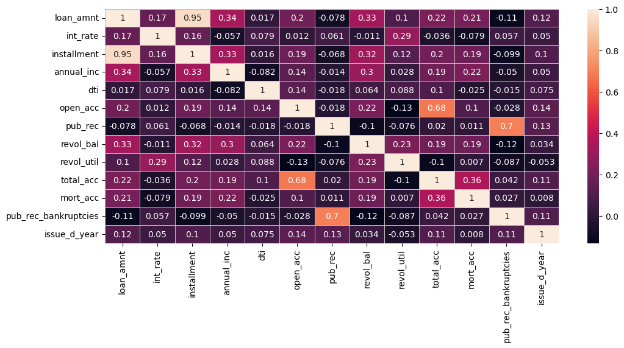

```python
plt.figure(figsize=(12,5))
sns.heatmap(df.corr(), annot=True, linecolor="silver", linewidths="0.6")
plt.show()
```

# Outliers Treatment

```python
q1 = np.quantile(df['loan_amnt'], 0.25)
q3 = np.quantile(df['loan_amnt'], 0.75)
IQR = q3-q1
Lower_whisker = q1-1.5*IQR
upper_whisker = q3+1.5*IQR
df[(df['loan_amnt'] < Lower_whisker) | (df['loan_amnt'] > upper_whisker)]
df = df[(df['loan_amnt'] > Lower_whisker) & (df['loan_amnt'] < upper_whisker)]
df.shape
```

```
(395836, 25)
```

```python
q1 = np.quantile(df['int_rate'], 0.25)
q3 = np.quantile(df['int_rate'], 0.75)
IQR = q3-q1
Lower_whisker = q1-1.5*IQR
upper_whisker = q3+1.5*IQR
df[(df['int_rate'] < Lower_whisker) | (df['int_rate'] > upper_whisker)][:5]
```

|  | loan_amnt | term | int_rate | installment | grade | sub_grade | emp_length | home_ownership | annual_inc | verification_status | ... | revol_bal | revol_util | total_acc | initial_list_status | application_type | mort_acc | pub_rec_bankruptcies | earliest_year | pin_code | issue_d_year |
| --- | --- | --- | --- | --- | --- | --- | --- | --- | --- | --- | --- | --- | --- | --- | --- | --- | --- | --- | --- | --- | --- |
| 96 | 12625.0 | 60 months | 25.78 | 376.36 | F | F5 | 7 years | MORTGAGE | 43000.0 | Verified | ... | 19993.0 | 55.7 | 31.0 | w | INDIVIDUAL | 1.0 | 0.0 | 2003 | 00813 | 2015 |
| 97 | 13400.0 | 60 months | 25.83 | 399.86 | G | G2 | 10+ years | MORTGAGE | 56000.0 | Verified | ... | 28845.0 | 84.5 | 44.0 | w | INDIVIDUAL | 6.0 | 0.0 | 2001 | 93700 | 2014 |
| 133 | 13075.0 | 60 months | 27.31 | 401.68 | G | G2 | 10+ years | MORTGAGE | 54777.0 | Source Verified | ... | 3845.0 | 59.2 | 27.0 | f | INDIVIDUAL | 2.0 | 0.0 | 2000 | 48052 | 2015 |
| 168 | 11800.0 | 60 months | 28.99 | 374.49 | G | G5 | 10+ years | RENT | 44011.0 | Verified | ... | 6313.0 | 67.2 | 13.0 | f | INDIVIDUAL | 0.0 | 1.0 | 2004 | 22690 | 2016 |
| 204 | 34350.0 | 60 months | 28.99 | 1090.13 | G | G5 | 3 years | RENT | 84000.0 | Verified | ... | 8400.0 | 85.7 | 23.0 | w | INDIVIDUAL | 0.0 | 1.0 | 2003 | 22690 | 2016 |

5 rows × 25 columns

Regarding the interest rate, numerous outliers are present in the dataset. However, it's essential to note that these outliers play a significant role in the data, as they are influenced by factors such as loan amount and tenure. Therefore, it is advisable not to remove these outliers from the dataset, as they contribute valuable information to our analysis.

```python
q1 = np.quantile(df['installment'], 0.25)
q3 = np.quantile(df['installment'], 0.75)
IQR = q3-q1
Lower_whisker = q1-1.5*IQR
upper_whisker = q3+1.5*IQR
df[(df['installment'] < Lower_whisker) | (df['installment'] > upper_whisker)][:5]
```

|  | loan_amnt | term | int_rate | installment | grade | sub_grade | emp_length | home_ownership | annual_inc | verification_status | ... | revol_bal | revol_util | total_acc | initial_list_status | application_type | mort_acc | pub_rec_bankruptcies | earliest_year | pin_code | issue_d_year |
| --- | --- | --- | --- | --- | --- | --- | --- | --- | --- | --- | --- | --- | --- | --- | --- | --- | --- | --- | --- | --- | --- |
| 11 | 35000.0 | 36 months | 14.64 | 1207.13 | C | C3 | 8 years | MORTGAGE | 130000.00 | Verified | ... | 81263.0 | 18.7 | 61.0 | w | INDIVIDUAL | 4.0 | 0.0 | 1984 | 00813 | 2014 |
| 18 | 34000.0 | 36 months | 7.90 | 1063.87 | A | A4 | 10+ years | RENT | 130580.00 | Verified | ... | 8767.0 | 11.9 | 36.0 | f | INDIVIDUAL | 3.0 | 0.0 | 1990 | 70466 | 2014 |
| 57 | 35000.0 | 36 months | 14.16 | 1198.94 | C | C2 | 9 years | MORTGAGE | 118497.84 | Verified | ... | 8148.0 | 83.1 | 59.0 | f | INDIVIDUAL | 3.0 | 0.0 | 1995 | 29597 | 2014 |
| 95 | 30000.0 | 36 months | 16.49 | 1061.99 | D | D3 | 10+ years | RENT | 101000.00 | Verified | ... | 6080.0 | 76.0 | 15.0 | f | INDIVIDUAL | 2.0 | 1.0 | 2003 | 70466 | 2014 |
| 103 | 30000.0 | 36 months | 15.31 | 1044.52 | C | C2 | 9 years | MORTGAGE | 108000.00 | Verified | ... | 19430.0 | 84.8 | 15.0 | w | INDIVIDUAL | 0.0 | 0.0 | 1998 | 93700 | 2012 |

5 rows × 25 columns

```python
q1 = np.quantile(df['annual_inc'], 0.25)
q3 = np.quantile(df['annual_inc'], 0.75)
IQR = q3-q1
Lower_whisker = q1-1.5*IQR
upper_whisker = q3+1.5*IQR
df[(df['annual_inc'] < Lower_whisker) | (df['annual_inc'] > upper_whisker)][:5]
```

|  | loan_amnt | term | int_rate | installment | grade | sub_grade | emp_length | home_ownership | annual_inc | verification_status | ... | revol_bal | revol_util | total_acc | initial_list_status | application_type | mort_acc | pub_rec_bankruptcies | earliest_year | pin_code | issue_d_year |
| --- | --- | --- | --- | --- | --- | --- | --- | --- | --- | --- | --- | --- | --- | --- | --- | --- | --- | --- | --- | --- | --- |
| 87 | 30000.0 | 60 months | 24.70 | 875.28 | G | G1 | 5 years | MORTGAGE | 187321.0 | Verified | ... | 54810.0 | 93.4 | 52.0 | f | INDIVIDUAL | 3.000000 | 0.0 | 2002 | 29597 | 2012 |
| 139 | 20000.0 | 36 months | 10.37 | 648.83 | B | B3 | < 1 year | MORTGAGE | 170000.0 | Verified | ... | 140820.0 | 76.2 | 19.0 | f | INDIVIDUAL | 1.813991 | 0.0 | 1990 | 22690 | 2011 |
| 195 | 24000.0 | 60 months | 24.50 | 697.42 | F | F3 | 10+ years | MORTGAGE | 224000.0 | Verified | ... | 5807.0 | 58.1 | 32.0 | f | INDIVIDUAL | 6.000000 | 0.0 | 2001 | 11650 | 2014 |
| 221 | 25000.0 | 60 months | 12.49 | 562.33 | B | B5 | 10+ years | RENT | 170000.0 | Verified | ... | 2390.0 | 5.4 | 13.0 | f | INDIVIDUAL | 0.000000 | 0.0 | 1998 | 05113 | 2014 |
| 228 | 35000.0 | 36 months | 12.99 | 1179.12 | C | C2 | 10+ years | MORTGAGE | 350000.0 | Verified | ... | 216194.0 | 45.4 | 43.0 | w | INDIVIDUAL | 2.000000 | 0.0 | 1992 | 70466 | 2016 |

5 rows × 25 columns

```python
q1 = np.quantile(df['open_acc'], 0.25)
q3 = np.quantile(df['open_acc'], 0.75)
IQR = q3-q1
Lower_whisker = q1-1.5*IQR
upper_whisker = q3+1.5*IQR
df[(df['open_acc'] < Lower_whisker) | (df['open_acc'] > upper_whisker)][:5]
```

|  | loan_amnt | term | int_rate | installment | grade | sub_grade | emp_length | home_ownership | annual_inc | verification_status | ... | revol_bal | revol_util | total_acc | initial_list_status | application_type | mort_acc | pub_rec_bankruptcies | earliest_year | pin_code | issue_d_year |
| --- | --- | --- | --- | --- | --- | --- | --- | --- | --- | --- | --- | --- | --- | --- | --- | --- | --- | --- | --- | --- | --- |
| 11 | 35000.0 | 36 months | 14.64 | 1207.13 | C | C3 | 8 years | MORTGAGE | 130000.0 | Verified | ... | 81263.0 | 18.7 | 61.0 | w | INDIVIDUAL | 4.0 | 0.0 | 1984 | 00813 | 2014 |
| 170 | 35000.0 | 60 months | 23.10 | 988.68 | E | E4 | 8 years | MORTGAGE | 125388.0 | Verified | ... | 128741.0 | 58.6 | 59.0 | f | INDIVIDUAL | 6.0 | 0.0 | 1984 | 48052 | 2013 |
| 191 | 35000.0 | 60 months | 17.57 | 880.61 | D | D4 | 10+ years | MORTGAGE | 150000.0 | Source Verified | ... | 44777.0 | 62.7 | 52.0 | f | INDIVIDUAL | 1.0 | 0.0 | 1998 | 11650 | 2015 |
| 346 | 20400.0 | 60 months | 18.24 | 520.70 | D | D5 | 4 years | RENT | 51000.0 | Source Verified | ... | 13284.0 | 26.0 | 38.0 | w | INDIVIDUAL | 0.0 | 0.0 | 1994 | 93700 | 2014 |
| 364 | 25000.0 | 60 months | 11.44 | 549.07 | B | B4 | 10+ years | MORTGAGE | 99000.0 | Verified | ... | 29067.0 | 39.2 | 49.0 | w | INDIVIDUAL | 3.0 | 0.0 | 1981 | 30723 | 2015 |

5 rows × 25 columns

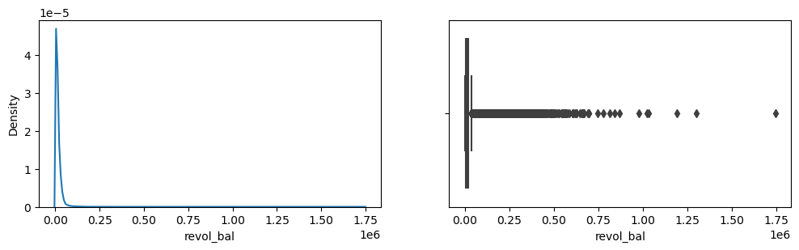

```python
plt.figure(figsize=(12,3))
plt.subplot(1,2,1)
sns.kdeplot(df['revol_bal'])
plt.subplot(1,2,2)
sns.boxplot(x=df['revol_bal'])
plt.show()
```

```python
q1 = np.quantile(df['revol_bal'], 0.25)
q3 = np.quantile(df['revol_bal'], 0.75)
IQR = q3-q1
Lower_whisker = q1-1.5*IQR
upper_whisker = q3+1.5*IQR
df[(df['revol_bal'] < Lower_whisker) | (df['revol_bal'] > upper_whisker)]
df = df[(df['revol_bal'] > Lower_whisker) & (df['revol_bal'] < upper_whisker)]
```

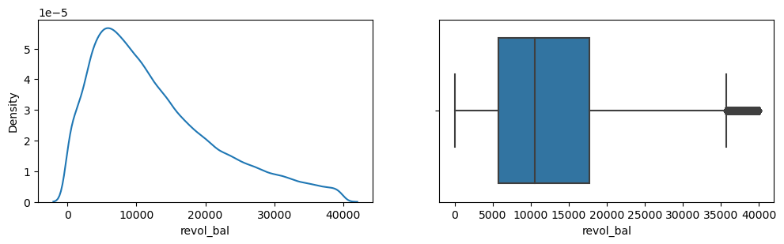

```python
plt.figure(figsize=(12,3))
plt.subplot(1,2,1)
sns.kdeplot(df['revol_bal'])
plt.subplot(1,2,2)
sns.boxplot(x=df['revol_bal'])
plt.show()
```

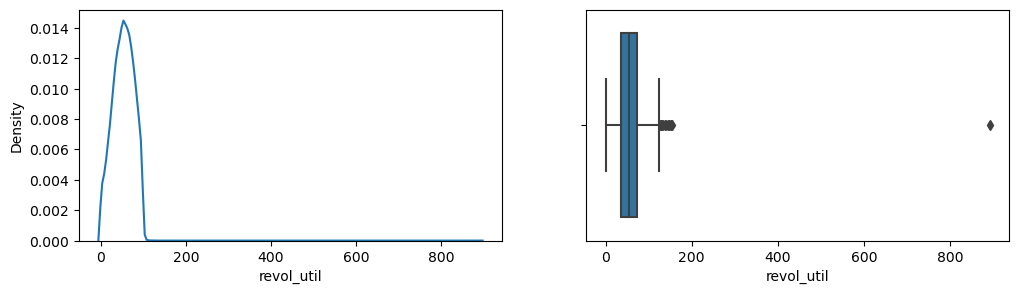

```python
plt.figure(figsize=(12,3))
plt.subplot(1,2,1)
sns.kdeplot(df['revol_util'])
plt.subplot(1,2,2)
sns.boxplot(x=df['revol_util'])
plt.show()
```

```python
q1 = np.quantile(df['revol_util'], 0.25)
q3 = np.quantile(df['revol_util'], 0.75)
IQR = q3-q1
Lower_whisker = q1-1.5*IQR
upper_whisker = q3+1.5*IQR
df[(df['revol_util'] < Lower_whisker) | (df['revol_util'] > upper_whisker)]
df = df[(df['revol_util'] > Lower_whisker) & (df['revol_util'] < upper_whisker)]
```

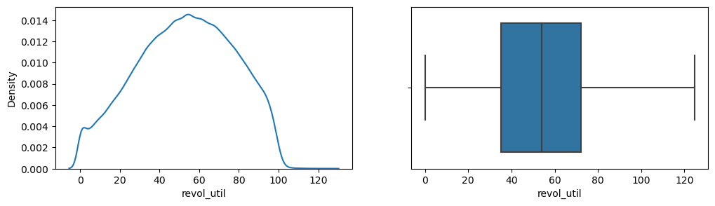

```python
plt.figure(figsize=(12,3))
plt.subplot(1,2,1)
sns.kdeplot(df['revol_util'])
plt.subplot(1,2,2)
sns.boxplot(x=df['revol_util'])
plt.show()
```

Currently, the data exhibits a closer approximation to a normal distribution. Furthermore, examination through the boxplot indicates an absence of outliers. With these observations, the data is now primed for accurate prediction and formulation, enhancing its overall quality and reliability.

# Feature Engineering

Converting the 'term' column, which contains object values representing terms in months, into integer values for 36 months and 60 months in the dataset.

### performing Label Encoding for the column initial_list_status

```python
le = LabelEncoder()
le
```

```
LabelEncoder()
```

```python
df['loan_status'] = df['loan_status'].replace('Fully Paid', 1)
df['loan_status'] = df['loan_status'].replace('Charged Off', 0)
df['loan_status']
```

```
0         1
1         1
2         1
3         1
4         0
         ..
396024    1
396025    1
396027    1
396028    1
396029    1
Name: loan_status, Length: 374589, dtype: category
Categories (2, int64): [0, 1]
```

```python
df['initial_list_status'] = le.fit_transform(df['initial_list_status'])
```

```python
df['initial_list_status'][:5]
```

```
0    1
1    0
2    0
3    0
4    0
Name: initial_list_status, dtype: int32
```

Label encoding was applied to the "status" column, representing whether individuals obtained loan approval ("w" for "approved") or not ("f" for "not approved"). In this encoding scheme, "w" is represented as 1 and "f" as 0 in the dataset.

```python
df['months'] = df['term'].str.split(' ').str[-2]
df['months'] = pd.to_numeric(df['months'])
df['emp_length'] = df['emp_length'].str.split(" ").str[-2]
df['updt_emp_length_yrs'] = df['emp_length'].replace('10+', '10')
df['updt_emp_length_yrs'] = pd.to_numeric(df['updt_emp_length_yrs'])
df = df.drop(columns= ['term', 'emp_length'])
```

### Performing the Target column Loan status

```python
df['loan_status'] = le.fit_transform(df['loan_status'])
```

```python
df['loan_status'][:5]
```

```
0    1
1    1
2    1
3    1
4    0
Name: loan_status, dtype: int64
```

To prepare the dataset for logistic regression modeling and analysis, we will focus on retaining the most relevant columns while eliminating unnecessary ones. This ensures that the data is streamlined for effective modeling, prioritizing features essential for the analysis.

```python
# df.drop(columns=['sub_grade', 'emp_length'], axis=1, inplace=True)
```

```python
df.shape
```

```
(374589, 25)
```

### Performing One hot encoding or with the Dummies for the Modelling

```python
df[:2]
```

|  | loan_amnt | int_rate | installment | grade | sub_grade | home_ownership | annual_inc | verification_status | loan_status | purpose | ... | total_acc | initial_list_status | application_type | mort_acc | pub_rec_bankruptcies | earliest_year | pin_code | issue_d_year | months | updt_emp_length_yrs |
| --- | --- | --- | --- | --- | --- | --- | --- | --- | --- | --- | --- | --- | --- | --- | --- | --- | --- | --- | --- | --- | --- |
| 0 | 10000.0 | 11.44 | 329.48 | B | B4 | RENT | 117000.0 | Not Verified | 1 | vacation | ... | 25.0 | 1 | INDIVIDUAL | 0.0 | 0.0 | 1990 | 22690 | 2015 | 36 | 10 |
| 1 | 8000.0 | 11.99 | 265.68 | B | B5 | MORTGAGE | 65000.0 | Not Verified | 1 | debt_consolidation | ... | 27.0 | 0 | INDIVIDUAL | 3.0 | 0.0 | 2004 | 05113 | 2015 | 36 | 4 |

2 rows × 25 columns

```python
for i in ('grade', 'sub_grade', 'home_ownership', 'verification_status', 'purpose', 'initial_list_status', 'application_type', 'pin_code'):
    df[i] = df[i].astype(str)
df['earliest_year'] = df['earliest_year'].astype(int)
```

# Data Prepration for Modelling

```python
X = df.drop(columns= ['loan_status'])
y = df['loan_status']
```

```python
for i in ('grade', 'sub_grade','home_ownership', 'purpose','verification_status', 'initial_list_status', 'application_type', 'pin_code'):

  # Fit and transform the categorical column
  X[i] = le.fit_transform(X[i])
```

We will now proceed to prepare the dataset for the testing and training phases of the algorithm.

```python
X.info()
```

```
<class 'pandas.core.frame.DataFrame'>
Int64Index: 374589 entries, 0 to 396029
Data columns (total 24 columns):
 #   Column                Non-Null Count   Dtype
---  ------                --------------   -----
 0   loan_amnt             374589 non-null  float64
 1   int_rate              374589 non-null  float64
 2   installment           374589 non-null  float64
 3   grade                 374589 non-null  int32
 4   sub_grade             374589 non-null  int32
 5   home_ownership        374589 non-null  int32
 6   annual_inc            374589 non-null  float64
 7   verification_status   374589 non-null  int32
 8   purpose               374589 non-null  int32
 9   dti                   374589 non-null  float64
```

[output cut: 16 more lines]

```python
print(X.shape)
print(y.shape)
```

```
(374589, 24)
(374589,)
```

```python
X_train, X_test, y_train, y_test = train_test_split(X, y, test_size=0.3, random_state = 42)
X_val, X_test, y_val, y_test = train_test_split(X_test, y_test, test_size=0.5, random_state = 43)
```

```python
print(X_train.shape)
print(y_train.shape)
print(X_val.shape)
print(y_val.shape)
print(X_test.shape)
print(y_test.shape)
```

```
(262212, 24)
(262212,)
(56188, 24)
(56188,)
(56189, 24)
(56189,)
```

```python
X_train[:2]
```

|  | loan_amnt | int_rate | installment | grade | sub_grade | home_ownership | annual_inc | verification_status | purpose | dti | ... | total_acc | initial_list_status | application_type | mort_acc | pub_rec_bankruptcies | earliest_year | pin_code | issue_d_year | months | updt_emp_length_yrs |
| --- | --- | --- | --- | --- | --- | --- | --- | --- | --- | --- | --- | --- | --- | --- | --- | --- | --- | --- | --- | --- | --- |
| 365865 | 5600.0 | 14.64 | 193.15 | 2 | 12 | 5 | 65000.0 | 2 | 9 | 3.45 | ... | 23.0 | 0 | 1 | 0.0 | 0.0 | 1993 | 4 | 2014 | 36 | 10 |
| 302179 | 10000.0 | 12.35 | 333.82 | 1 | 8 | 5 | 59000.0 | 0 | 1 | 15.07 | ... | 15.0 | 1 | 1 | 0.0 | 0.0 | 2000 | 1 | 2013 | 36 | 10 |

2 rows × 24 columns

```python
X_test[:2]
```

|  | loan_amnt | int_rate | installment | grade | sub_grade | home_ownership | annual_inc | verification_status | purpose | dti | ... | total_acc | initial_list_status | application_type | mort_acc | pub_rec_bankruptcies | earliest_year | pin_code | issue_d_year | months | updt_emp_length_yrs |
| --- | --- | --- | --- | --- | --- | --- | --- | --- | --- | --- | --- | --- | --- | --- | --- | --- | --- | --- | --- | --- | --- |
| 78071 | 9600.0 | 15.10 | 333.26 | 2 | 11 | 5 | 55000.0 | 0 | 2 | 13.37 | ... | 17.0 | 0 | 1 | 0.0 | 0.0 | 1999 | 6 | 2013 | 36 | 7 |
| 70575 | 2000.0 | 11.53 | 65.99 | 1 | 9 | 1 | 75000.0 | 1 | 2 | 9.14 | ... | 48.0 | 1 | 1 | 7.0 | 0.0 | 1997 | 4 | 2015 | 36 | 10 |

2 rows × 24 columns

```python
y_train.value_counts()
```

```
1    210476
0     51736
Name: loan_status, dtype: int64
```

The value counts above reveal an imbalance in the distribution of outcomes '1' and '0' within the dataset. To address this imbalance, the SMOTE (Synthetic Minority Over-sampling Technique) method can be employed. SMOTE oversamples the minority class by generating synthetic instances based on nearest neighbor concepts. It's important to note that oversampling will only be applied to the training data. This ensures that the model is trained on balanced data while maintaining the original distribution of outcomes in the validation and testing datasets.

```python
smote = SMOTE(random_state=42)
X_train, y_train = smote.fit_resample(X_train, y_train)
```

```python
print(f'Traning Data:\n{y_train.value_counts()}')
```

```
Traning Data:
1    210476
0    210476
Name: loan_status, dtype: int64
```

# Assumptions Multicollinearity checking by VIF score

```python
vif_data = pd.DataFrame()
vif_data["Variable"] = X_train.columns
vif_data["VIF"] = [variance_inflation_factor(X_train.values, i) for i in range(X_train.shape[1])]

print(pd.DataFrame(vif_data))
```

```
                Variable            VIF
0              loan_amnt     257.866661
1               int_rate     269.152951
2            installment     228.379674
3                  grade      44.503696
4              sub_grade     162.920909
5         home_ownership       4.868108
6             annual_inc       3.667949
7    verification_status       2.911988
8                purpose       2.609311
9                    dti       2.050460
10              open_acc      14.613731
11               pub_rec       1.921632
12             revol_bal       5.942522
13            revol_util      10.524961
14             total_acc      14.072434
15   initial_list_status       1.541549
16      application_type     523.365395
17              mort_acc       2.757326
18  pub_rec_bankruptcies       2.017873
19         earliest_year  112339.858234
20              pin_code       4.781091
21          issue_d_year  113530.703874
22                months     132.428650
23   updt_emp_length_yrs       4.709353
```

Based on the VIF (Variance Inflation Factor) values observed above, it is evident that several columns exhibit collinearity, as indicated by high VIF scores. Collinearity must be addressed to uphold the stability and interpretability of the model.

```python
X_train = X_train.drop(columns= ['installment' , 'sub_grade', 'total_acc', 'application_type', 'issue_d_year', 'int_rate', 'earliest_year', 'months'])
```

```python
vif_data = pd.DataFrame()
vif_data["Variable"] = X_train.columns
vif_data["VIF"] = [variance_inflation_factor(X_train.values, i) for i in range(X_train.shape[1])]

print(vif_data.sort_values(by=['VIF'],ascending=False))
```

```
                Variable       VIF
10            revol_util  7.751816
7               open_acc  6.591057
0              loan_amnt  6.337188
9              revol_bal  5.557774
1                  grade  4.308686
14              pin_code  4.296104
15   updt_emp_length_yrs  4.096614
2         home_ownership  3.746142
3             annual_inc  3.567457
4    verification_status  2.887075
5                purpose  2.334305
12              mort_acc  2.293153
6                    dti  2.026394
13  pub_rec_bankruptcies  1.993900
8                pub_rec  1.913557
11   initial_list_status  1.448615
```

Remove the collinear columns from validation and testing data also to get and fit the responsiveness of the Data with the equal shape and size

```python
X_val = X_val.drop(columns= ['installment' , 'sub_grade', 'total_acc', 'application_type', 'issue_d_year', 'int_rate', 'earliest_year', 'months'])
X_test = X_test.drop(columns= ['installment' , 'sub_grade', 'total_acc', 'application_type', 'issue_d_year', 'int_rate', 'earliest_year', 'months'])
```

# Scaling Via MinMax()

The MinMaxScaler operates by scaling each feature's values to a range between 0 and 1. This is achieved by subtracting the minimum value from each feature and then dividing by the range, which is the difference between the original maximum and original minimum values. By employing MinMaxScaler, the distribution's shape of the original data is maintained, ensuring that the intrinsic information within the dataset remains unchanged.

```python
scaling = MinMaxScaler()
scaling
```

```
MinMaxScaler()
```

```python
X_train = pd.DataFrame(scaling.fit_transform(X_train),columns=X_train.columns)
```

```python
X_train[:2]
```

|  | loan_amnt | grade | home_ownership | annual_inc | verification_status | purpose | dti | open_acc | pub_rec | revol_bal | revol_util | initial_list_status | mort_acc | pub_rec_bankruptcies | pin_code | updt_emp_length_yrs |
| --- | --- | --- | --- | --- | --- | --- | --- | --- | --- | --- | --- | --- | --- | --- | --- | --- |
| 0 | 0.136364 | 0.333333 | 1.0 | 0.008553 | 1.0 | 0.692308 | 0.000345 | 0.078947 | 0.0 | 0.103851 | 0.354451 | 0.0 | 0.0 | 0.0 | 0.444444 | 1.0 |
| 1 | 0.254011 | 0.166667 | 1.0 | 0.007763 | 0.0 | 0.076923 | 0.001507 | 0.078947 | 0.0 | 0.283946 | 0.711307 | 1.0 | 0.0 | 0.0 | 0.111111 | 1.0 |

```python
X_val = pd.DataFrame(scaling.transform(X_val), columns=X_val.columns)
X_val[:2]
```

|  | loan_amnt | grade | home_ownership | annual_inc | verification_status | purpose | dti | open_acc | pub_rec | revol_bal | revol_util | initial_list_status | mort_acc | pub_rec_bankruptcies | pin_code | updt_emp_length_yrs |
| --- | --- | --- | --- | --- | --- | --- | --- | --- | --- | --- | --- | --- | --- | --- | --- | --- |
| 0 | 0.183155 | 0.5 | 1.0 | 0.004605 | 0.5 | 0.384615 | 0.002912 | 0.236842 | 0.0 | 0.022081 | 0.150762 | 0.0 | 0.0000 | 0.0 | 0.444444 | 0.0 |
| 1 | 0.788770 | 0.5 | 0.2 | 0.009211 | 1.0 | 0.153846 | 0.001126 | 0.118421 | 0.0 | 0.329357 | 0.403368 | 0.0 | 0.0625 | 0.0 | 0.777778 | 1.0 |

```python
X_test = pd.DataFrame(scaling.transform(X_test),columns=X_test.columns)
X_test[:2]
```

|  | loan_amnt | grade | home_ownership | annual_inc | verification_status | purpose | dti | open_acc | pub_rec | revol_bal | revol_util | initial_list_status | mort_acc | pub_rec_bankruptcies | pin_code | updt_emp_length_yrs |
| --- | --- | --- | --- | --- | --- | --- | --- | --- | --- | --- | --- | --- | --- | --- | --- | --- |
| 0 | 0.243316 | 0.333333 | 1.0 | 0.007237 | 0.0 | 0.153846 | 0.001337 | 0.105263 | 0.0 | 0.234959 | 0.697674 | 0.0 | 0.00000 | 0.0 | 0.666667 | 0.666667 |
| 1 | 0.040107 | 0.166667 | 0.2 | 0.009868 | 0.5 | 0.153846 | 0.000914 | 0.197368 | 0.0 | 0.559690 | 0.620690 | 1.0 | 0.21875 | 0.0 | 0.444444 | 1.000000 |

### Lets Prepare for the Logistic Regression for the Analysis with the Algorithm

```python
lr = LogisticRegression(max_iter=1000)
lr
```

```
LogisticRegression(max_iter=1000)
```

```python
model = lr.fit(X_train, y_train)
model
```

```
LogisticRegression(max_iter=1000)
```

```python
pd.Series((zip(X.columns, model.coef_[0])))
```

```
0                (loan_amnt, -1.349134385232267)
1                 (int_rate, -1.977671290675377)
2             (installment, 0.12312602748120853)
3                     (grade, 26.04849519931264)
4                (sub_grade, 0.6299670007105354)
5           (home_ownership, 0.2547181707213342)
6              (annual_inc, -13.829807946184063)
7     (verification_status, -2.4226467318018714)
8                  (purpose, -9.038753142451876)
9                      (dti, 0.5811042549820186)
10               (open_acc, -1.0256686911344304)
11                 (pub_rec, 0.8365714784929329)
12               (revol_bal, 3.0094573265557214)
13            (revol_util, -0.27846648753621933)
14                (total_acc, -3.00122294537137)
15    (initial_list_status, 0.13943587550947964)
dtype: object
```

```python
y_predval = model.predict(X_val)
y_predval
```

```
array([0, 0, 1, ..., 0, 1, 0], dtype=int64)
```

```python
y_pred = model.predict(X_test)
y_pred
```

```
array([0, 1, 1, ..., 1, 0, 1], dtype=int64)
```

### Actual and predicted values for the validation Data

```python
test1 = pd.DataFrame({
    "Actual":y_val,
    "Predicted":y_predval
})
test1[:10]
```

|  | Actual | Predicted |
| --- | --- | --- |
| 151016 | 1 | 0 |
| 346251 | 0 | 0 |
| 352698 | 1 | 1 |
| 32684 | 1 | 0 |
| 7401 | 1 | 1 |
| 55279 | 1 | 0 |
| 240079 | 1 | 1 |
| 131477 | 1 | 1 |
| 216743 | 1 | 1 |
| 217320 | 1 | 0 |

### Actual and predicted values for the test Data

```python
test1 = pd.DataFrame({
    "Actual":y_test,
    "Predicted":y_pred
})
test1[:10]
```

|  | Actual | Predicted |
| --- | --- | --- |
| 78071 | 1 | 0 |
| 70575 | 1 | 1 |
| 319702 | 1 | 1 |
| 24059 | 1 | 1 |
| 129453 | 0 | 0 |
| 57366 | 1 | 1 |
| 330114 | 1 | 1 |
| 334179 | 1 | 1 |
| 126252 | 1 | 1 |
| 329008 | 1 | 1 |

```python
r2 = model.score(X_val, y_val)
r2
```

```
0.675233145867445
```

## Lets check for the Residuals

```python
Error = test1["Actual"] - test1["Predicted"]
Error.mean()
```

```
0.18975244264891705
```

# Checking for Adjusted R2

Formula : 1 - (1- r2)*(n-1)/(n-d-1) where: r2 is the Score n is the no of Rows d is the no.features

```python
n , d =X_val.shape
print("Number of Rows:",n,"Features",d)
Numerator = (1-r2)*(n-1)
Denominator = (n-d-1)
1 - (Numerator/Denominator)
```

```
Number of Rows: 56188 Features 16
```

```
0.6751406378176306
```

### Training prediction score

```python
model.score(X_train, y_train)
```

```
0.6923568482867405
```

### Testing data predicting Score

```python
model.score(X_test, y_test)
```

```
0.6773745750947694
```

# Checking for Confusion metrics

```python
cm = confusion_matrix(y_test, y_pred)
cm
```

```
array([[ 7419,  3733],
       [14395, 30642]], dtype=int64)
```

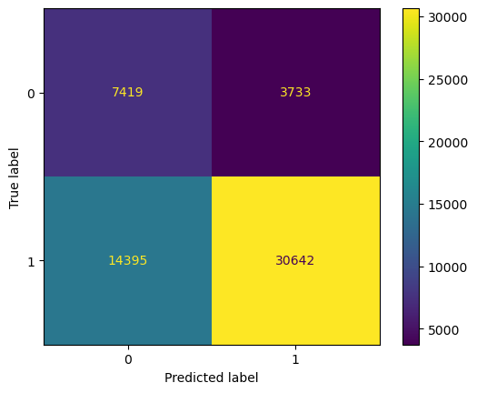

```python
ConfusionMatrixDisplay(cm).plot();
```

```python
print(classification_report(y_test, y_pred))
```

```
              precision    recall  f1-score   support

           0       0.34      0.67      0.45     11152
           1       0.89      0.68      0.77     45037

    accuracy                           0.68     56189
   macro avg       0.62      0.67      0.61     56189
weighted avg       0.78      0.68      0.71     56189
```

## Precision Score

Precision measures the proportion of correctly predicted positive instances out of all instances that the model predicted as positive in the dataset.

```python
P = precision_score(y_test, y_pred)
P
```

```
0.8914036363636364
```

# Recall Score

Recall measures the how many actual positive items were correctly idetified by the model

```python
R = recall_score(y_test, y_pred)
R
```

```
0.6803739147811799
```

# F1 Score

F1 score is a single metric that combines precision and recall. It provides a balance between the two by calculating the harmonic mean of precision and recall. This means it considers both false positives and false negatives when evaluating the model's performance. A higher F1 score indicates better overall performance, taking into account both precision and recall. Formula for F1 score 2*P*R/ P+R

```python
f1_score(y_test, y_pred)
```

```
0.771722157860273
```

### Checking the Probabilites for the Class 0 and Class 1

We typically examine the probabilities and predicted values for class 1 when assessing each class's probabilities and predictions, including class 0 and class 1. The below values for the Probability for the class 0 for the First column and class 1 for the second columns

```python
Probability = model.predict_proba(X_test)
Probability[:10]
```

```
array([[0.77002397, 0.22997603],
       [0.12575388, 0.87424612],
       [0.27213132, 0.72786868],
       [0.19178799, 0.80821201],
       [0.59582011, 0.40417989],
       [0.08778016, 0.91221984],
       [0.15030727, 0.84969273],
       [0.11144616, 0.88855384],
       [0.14334422, 0.85665578],
       [0.15994047, 0.84005953]])
```

Here we are extracting the for the class 1 probabilities beacause , we always used to predict the values for the class 1, to check the actual and the predicted values, where the certain model is predicting for the actual 1 in the predicted values or not.

```python
probabilities = Probability[:, 1]
probabilities
```

```
array([0.22997603, 0.87424612, 0.72786868, ..., 0.75310349, 0.41182084,
       0.7962986 ])
```

### Checking the TPR with Respect to FPR using ROC Curve

We commonly utilize the ROC curve to evaluate the performance of a model by comparing the actual test values with the predicted probabilities. This enables us to determine the true positive rate (TPR) at different thresholds, visualizing how the model's predictions align with the actual outcomes through the ROC graph.

```python
fpr, tpr, threshold = roc_curve(y_test, probabilities)
```

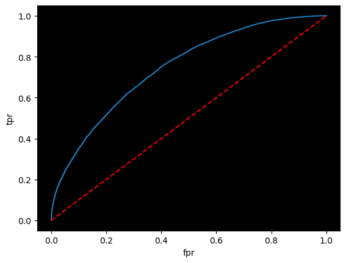

```python
plt.plot(fpr, tpr)
plt.plot([0,1], [0, 1], '--', color='red')
plt.gca().set_facecolor("black")
plt.xlabel("fpr")
plt.ylabel("tpr");
```

### Checking for the roc_auc_score for the above graph

```python
roc_auc_score(y_test, probabilities)
```

```
0.7457407808386084
```

### Analysing the Precision Recalll Curve

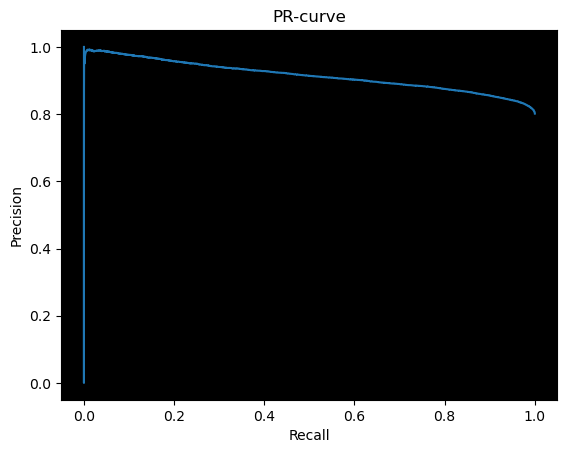

```python
precision, recall, threshold = precision_recall_curve(y_test, probabilities)
plt.plot(recall, precision)

plt.xlabel('Recall')
plt.ylabel('Precision')
plt.title('PR-curve')
plt.gca().set_facecolor("black")
plt.show()
```

# Insights and Recommendations